# How to Mizer - how to calibrate/refine a mizer model to time-averaged catch data

Julia L. Blanchard, Ken H. Andersen, Gustav Delius, Romain Forestier

2021-04-19

# Intermediate level tutorial - how to calibrate a Mizer model

In this tutorial you will learn

- How to refine key parameters using optimization so the model is in the right ballpark as the data
- Simple calibration protocol - shown sequentially for Rmax, kappa and eRepro
- Introduce rShiny for model exploration

We finished HTM0 with a manually parametrised model with species coexisting, now we want our model to reflect reality. To do so we are going to compare the model output to data by matching catch, biomass and/or growth rate depending on what is available.

## Step 1. Calibrate the maximum recruitment

In this section you will:

- use a package that will calibrate $R_{max}$ per species

$Rmax$ will affect the relative biomass of each species (and, combined with the fishing parameters, the catches) by minimising the error between observed and estimated catches or biomasses. We could also include $\kappa$ in our estimation here (as in Blanchard et al 2104 & Spence et al 2016) but instead we will use the value that seemed OK in terms of feeding levels in the Rshiny app, roughly $log10(11.5)$. Same goes for $erepro$, a value of $1e-3$ seemed ok.

First let’s set up a function running the model and outputing the difference between predicted catches (`getYield()`) and actual catches (`catchAvg`). `err` is the sum of squared errors between the two.

```r
# we need 12 Rmaxs, log10 scale
vary <- log10(params_guessed@species_params$R_max)
#vary<-runif(10,3,12) # or use completley made up values, same for each species test for effects of initial values

## set up the enviornment to keep the current state of the simulations
state <- new.env(parent = emptyenv())
state$params <-  params_guessed

#catchAvg <-read.csv("data/time-averaged-catches.csv") # only that one is used at the moment | catches are estimated from fMatW

## test it
err<-getError(vary = vary, params = params_guessed, dat = catchAvg$Catch_1419_tonnes)
```

```
## Convergence was achieved in 84 years.
```

```r
# err<-getError(vary,params,dat=rep(100,12),data_type="biomass")
err
```

```
## [1] 76.95525
```

Now, carry out the optimisation. There are several optimisation methods to choose from - we need to select the most robust one to share here. The R package optimParallel seems to be the most robust general R package and has replaced optim. Often this requires repeateing the proceure several times but the advantage of using parallel run is the speed compared to packages such as optimx.

This might take AWHILE. The output is saved as “optim_para_result” if you wish to skip this block.

```r
# change kappa and erepro based on shiny exploration, set up initial values based on "close to" equilibrium values from above sim
# params_steady already set to erepro = 0.001 and kappa = 10^11

params_optim <- params_guessed
vary <-  log10(params_optim@species_params$R_max)


# params_optim@resource_params$kappa<-3.2e11 # better kappa estimated from Rshiny
params_optim<-setParams(params_optim)

noCores <- detectCores() - 5 # keep a spare core

cl <- makeCluster(noCores, setup_timeout = 0.5)
setDefaultCluster(cl = cl)
clusterExport(cl, as.list(ls()))
clusterEvalQ(cl, {
  library(mizerExperimental)
  library(optimParallel)
})

tic()
optim_result <-optimParallel(par=vary,getError,params=params_optim, dat = catchAvg$Catch_1419_tonnes, method   ="L-BFGS-B",lower=c(rep(3,12)),upper= c(rep(15,12)),
                            parallel=list(loginfo=TRUE, forward=TRUE))

stopCluster(cl)
toc() # 80'' using 47 cores
saveRDS(optim_result,"optimParallel_Rmax.RDS")
```

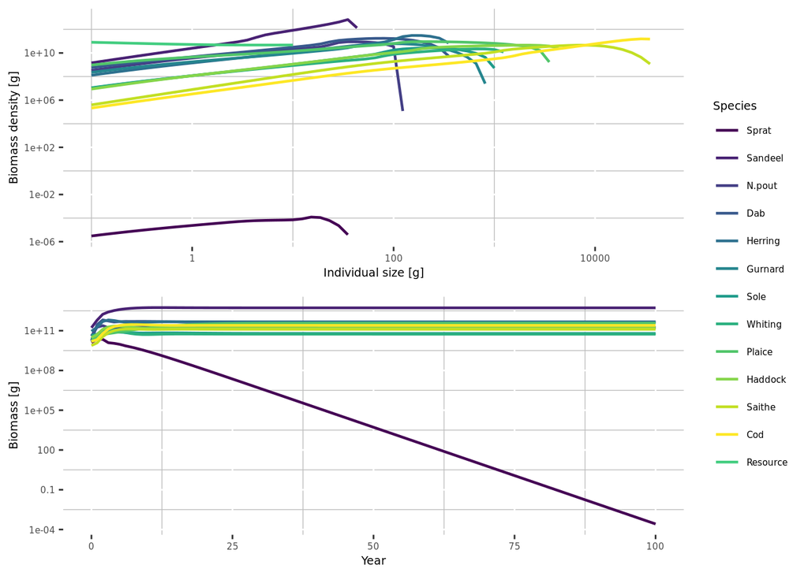

```r
# if previous block was not evaluated
params_optim <- params_guessed
# params_optim@resource_params$kappa<-3.2e11 # old value (keeping it for now cause it works)

optim_result <- readRDS("optimParallel_Rmax.RDS")
# optim values:
params_optim@species_params$R_max <- 10^optim_result$par

# set the param object
params_optim <-setParams(params_optim)
sim_optim <- project(params_optim, effort = 1, t_max = 100, dt=0.1,initial_n = sim_guessed@n[100,,],initial_n_pp = sim_guessed@n_pp[100,])
saveRDS(sim_optim,"sim_optim.RDS")
plotSummary(sim_optim, short = T)
```

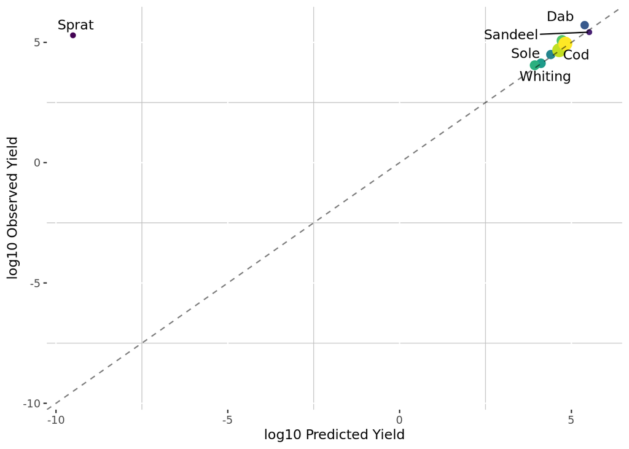

```r
plotPredObsYield(sim_optim,catchAvg$Catch_1419_tonnes)
```

Calibrating for best observed/predicted yield makes one species (Sprat) show signs of collapse. We need to look at other parameters to get the community to coexist again.

## Step 2. Calibrate the recruitment with eRepro.

In this section you will:

- Look at effect of $erepro$ on the reproductive outputs
- Check what impact erepro has on the $F_{msy}$

RF: shiny disabled for pdf

Now let’s take a look at the current $F_msy$ per species. To do so we need to set up an ecosystem with one gear per species and vary one gear intensity at a time while the other gear stay constant (default effort value of one).

```r
# Can be a bit long to not need to evaluate, just load the next block

plot_dat <- plotFmsy(params_optim, returnData = T, effortRes = 50)

saveRDS(plot_dat, "Fmsy.rds")
```

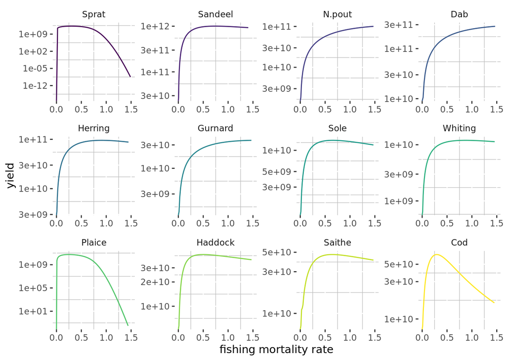

```r
plot_dat <- readRDS("Fmsy.rds")

ggplot(plot_dat) +
 geom_line(aes(x = effort , y = yield, color = species))+
  facet_wrap(species~., scales = "free") +
  scale_x_continuous(limits= c(0,1.5),name = "fishing mortality rate")+#, limits = c(1e10,NA))+
  scale_y_continuous(trans = "log10") +
  scale_color_manual(name = "Species", values = params_optim@linecolour) +
    theme(legend.position = "none", legend.key = element_rect(fill = "white"),
           panel.background = element_blank(), panel.grid.minor = element_line(color = "gray"),
          strip.background = element_blank())
```

Decreasing $eRepro$ is going to move the $MSY$ towards lower effort. Until now we had the same $eRepro$ for all species but we can input species-specific values to calibrate our recruitment. To do so, let’s use another shiny app again. The next one allows you to change $eRepro$ one at a time and see the effect on the species’ $F_{msy}$

RF: shiny disable for pdf

Let’s see what our system looks like with species-specific $eRepro$

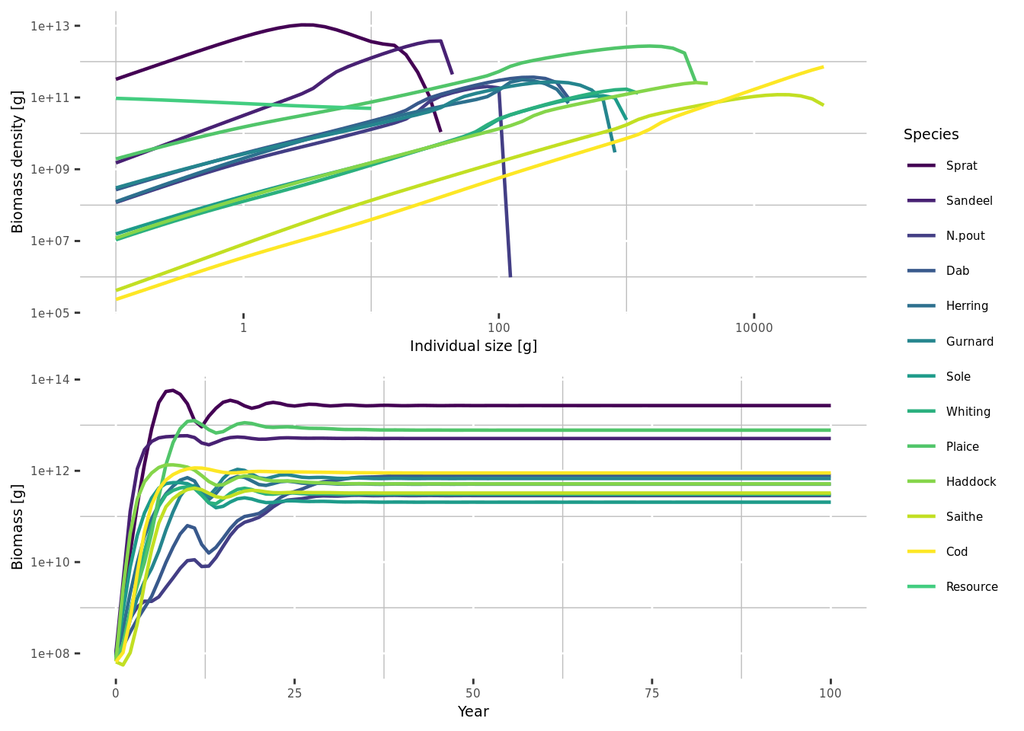

```r
params_optim@species_params$erepro <- 10^(c(-1,-2,-4,-4,-3,-3,-2,-3,-2,-2,-2,-2))

params_optim2 <- setParams(params_optim)
sim_optim2 <- project(params_optim2, effort = 1, t_max = 100)
plotSummary(sim_optim2, short = T)
```

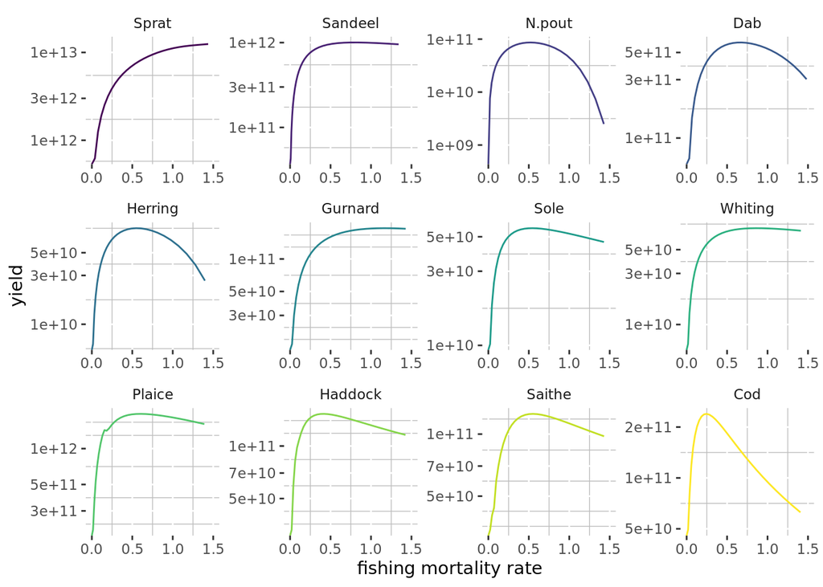

```r
plotFmsy(params_optim2, effortRes = 30, returnData = F)
```

```r
# saving the last time step of sim_optim2 in the param object
params_optim2@initial_n <- sim_optim2@n[dim(sim_optim2@n)[1],,]
params_optim2@initial_n_pp <- sim_optim2@n_pp[dim(sim_optim2@n_pp)[1],]

params_calibration <- params_optim2
vary <-  log10(params_calibration@species_params$R_max)
params_calibration<-setParams(params_calibration)

noCores <- detectCores() - 1 # keep a spare core

cl <- makeCluster(noCores, setup_timeout = 0.5)
setDefaultCluster(cl = cl)
clusterExport(cl, as.list(ls()))
clusterEvalQ(cl, {
  library(mizerExperimental)
  library(optimParallel)
})
```

[output not shown]

[output cut: 226 more lines]

[output not shown]

```r
tic()
optim_result <-optimParallel(par=vary,getError,params=params_calibration, dat = catchAvg$Catch_1419_tonnes,
                             method   ="L-BFGS-B",lower=c(rep(3,12)),upper= c(rep(15,12)),
                            parallel=list(loginfo=TRUE, forward=TRUE))

stopCluster(cl)
toc() # 80'' using 47 cores
```

```
## 148.304 sec elapsed
```

```r
saveRDS(optim_result,"optimParallel_Rmax2.RDS")
```

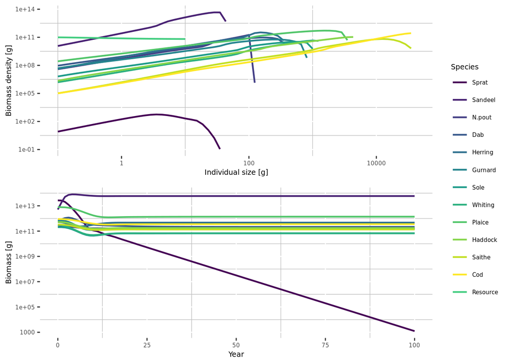

```r
optim_result <- readRDS("optimParallel_Rmax2.RDS")
# if previous block not evaluated
params_optim2@initial_n <- sim_optim2@n[dim(sim_optim2@n)[1],,]
params_optim2@initial_n_pp <- sim_optim2@n_pp[dim(sim_optim2@n_pp)[1],]

params_calibration <- params_optim2

# optim values:
params_calibration@species_params$R_max <- 10^optim_result$par

# set the param object
params_calibration <-setParams(params_calibration)
sim_optim2 <- project(params_calibration, effort = 1, t_max = 100, dt=0.1, initial_n = params_calibration@initial_n ,
                      initial_n_pp = params_calibration@initial_n_pp)
saveRDS(sim_optim2,"sim_optim2.RDS")
plotSummary(sim_optim2, short = T)
```

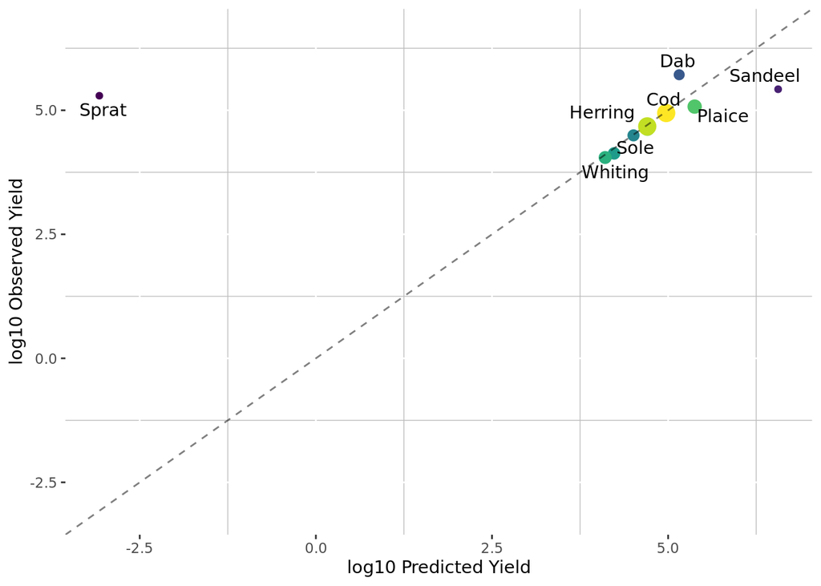

```r
plotPredObsYield(sim_optim2,catchAvg$Catch_1419_tonnes)
```

## Step 3. Calibrating the growth

In this section you will:

- look at the growth curves of each species
- tweak the $\kappa$ parameter to adjust the growth curves

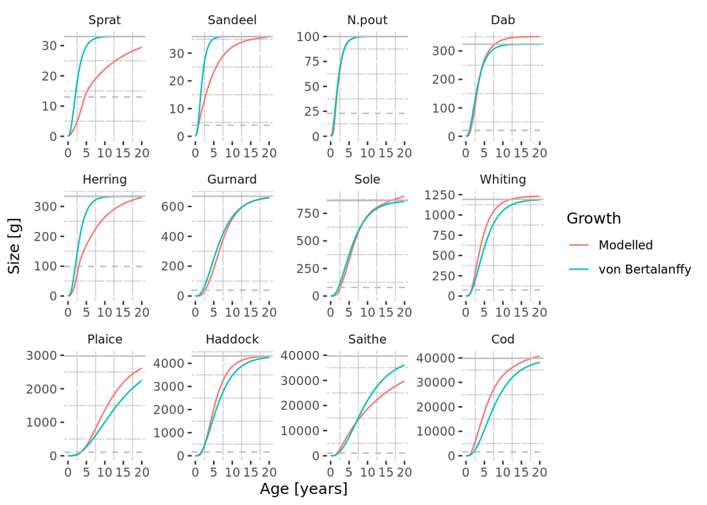

```r
plotGrowthCurves2(sim_optim2, species_panel = T)
```

```r
# Ken's comment: plotGrowthCurves. Legend should be “model”, “Observed”. Need to discuss about that since we need to change the plot in Mizer then
```

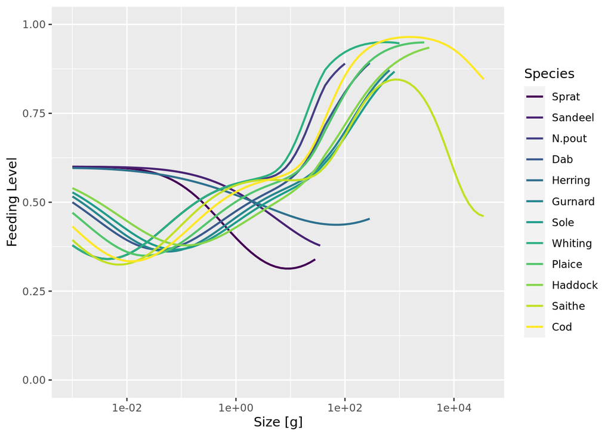

```r
plotFeedingLevel(sim_optim2, include_critical = F)
```

The feeding level here shows that the species reaching the highest size classes have a feeding level close to one, meaning that they feed to satiation. Let’s look at their diet to check what makes them to full.

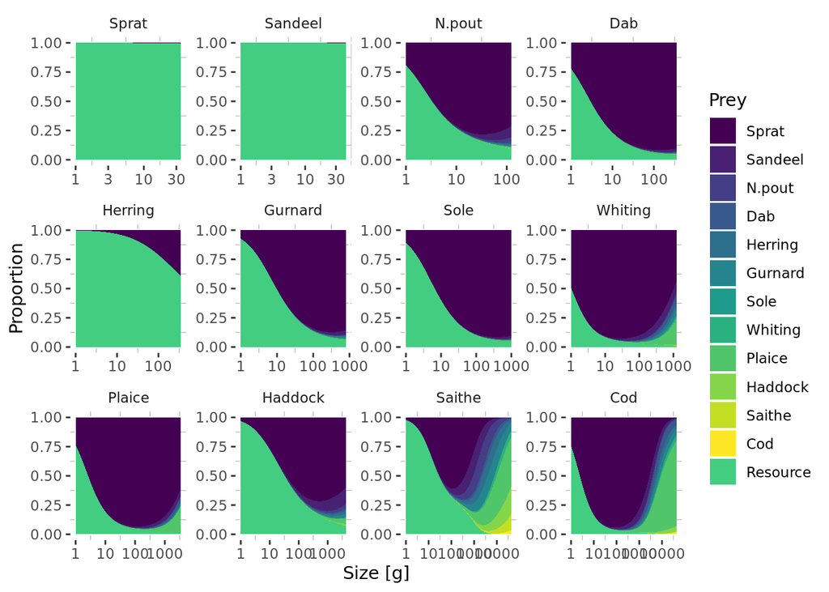

```r
# plotDiet2(sim_optim2, "Haddock")
# plotDiet2(sim_optim2, "Plaice")
# plotDiet2(sim_optim2, "Saithe")
plotDiet2(sim_optim2)
```

The diets look great as the fish feed on each other and do not rely too much on the background spectrum. We can still reduce the carrying capacity of the background spectrum even more, which could lower the feeding level of the species. Let’s do this using the Rshiny app

RF: Rshiny section disabled for pdf

Decreasing slightly $\kappa$ drives Sprat to extinction probably as it becomes the next choice of food when we reduce the size of the background spectrum (as we saw on the diet plots). So how can we reduce the feeding level of the largest predators while keeping Sprat alive?